# Team Charlotte Weekly Report

## Cleaning & Combining Data

### Installing Packages

```r
# install.packages("tidyverse")
# install.packages("ggmap")
# install.packages("maptiles")
# install.packages("terra")
# install.packages("leaflet")
# install.packages("tidycensus)
# install.packages("RColorBrewer")
```

### Loading Libraries

```r
library("tidyverse")
library("terra")
library("maptiles")
library("tidycensus")
library("RColorBrewer")
```

Gathered Data using Google API

We utilized the Google Maps API to obtain the coordinates (latitude and longitude) and the exact addresses of all the stations mentioned in our dataset. This process involved sending requests to the Google Maps API with station names and receiving detailed geolocation data in response.

However, due to GitHub’s policies on not publicly sharing API keys, we have not included the API key directly in our repository. Instead, we have preprocessed the data and saved the geocoded results in a CSV file named “new_station_coords_data.csv”

Cleaning Data

```r
addrs.geo <- read.csv("new_station_coords_data.csv")
new_addr <- addrs.geo %>%
  mutate(
    lat2 = ifelse(
      stations == "Bland Street station",
      35.21622,
      lat
    ),
    lon2 = ifelse(
      stations == "Bland Street station",
      -80.85446,
      lon
    ),
    address2 = ifelse(
      stations == "Bland Street station",
      "1511 Camden Road, charlotte, nc, usa", address

    )
  ) %>%
  mutate(
    lat2 = ifelse(
      stations == "Carson light rail station (Charlotte)",
      35.21944,
      lat2
    ),
    lon2 = ifelse(
      stations == "Carson light rail station (Charlotte)",
      -80.84823,
      lon2
    ),
    address2 = ifelse(
      stations == "Carson light rail station (Charlotte)",
      "218 East Carson Boulevard, charlotte, nc, usa",
      address2
    )
  ) %>%
  mutate(
    lat2 = ifelse(
      stations == "Charlotte Transportation Center",
      35.21944,
      lat2
    ),
    lon2 = ifelse(
      stations == "Charlotte Transportation Center",
      -80.84823,
      lon2
    ),
    address2 = ifelse(
      stations == "Charlotte Transportation Center",
      "310 East Trade Street, charlotte, nc, usa", address2
    )
  ) %>%


  mutate(
    lat2 = ifelse(
      stations == "JW Clay Blvd/UNC Charlotte station",
      35.31155,
      lat2
    ),
    lon2 = ifelse(
      stations == "JW Clay Blvd/UNC Charlotte station",
      -80.74547,
      lon2
    ),
    address2 = ifelse(
      stations == "JW Clay Blvd/UNC Charlotte station",
      "9048 North Tryon Street, charlotte, nc, usa", address2
    )
  )
```

Storing Data into new CSV File

```r
# First time users - do NOT over-wrrite CSV file
# write.csv(new_addr, "new_station_coords_data.csv", row.names = FALSE)
```

Storing Latitude and Longtitude

```r
sample_latlon <- cbind(new_addr$lon2, new_addr$lat2)
```

Storing into Vector Data

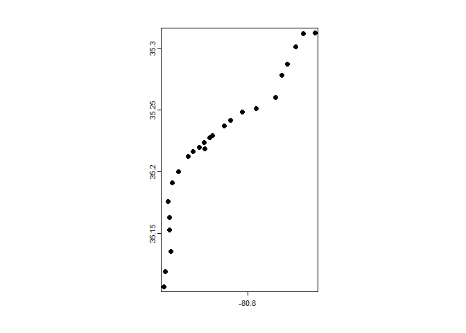

```r
pts <-  vect(sample_latlon)
crdref <- "+proj=longlat +datum=WGS84"
pts <- vect(sample_latlon, crs=crdref)
plot(pts)
```

### Finding PM2.5 Data

Due to the large size of the data files, the code execution was not included in the README file. For detailed information on how PM2.5 levels were extracted, please refer to the file “station_buffer_pm2.5.R”.

### Overlaying Stations with PM2.5

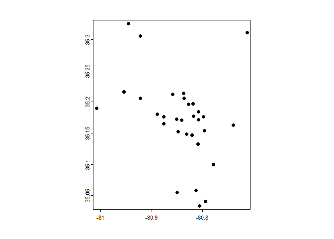

```r
# Plot Stations
x <- vect(sample_latlon, crs = "+proj=longlat +ellps=WGS84 +datum=WGS84 +no_defs")

# Plot Factors
pm_sources <- vect("PM2.5 ShapeFiles/new_pm_coords_sources.shp")
plot(pm_sources)
```

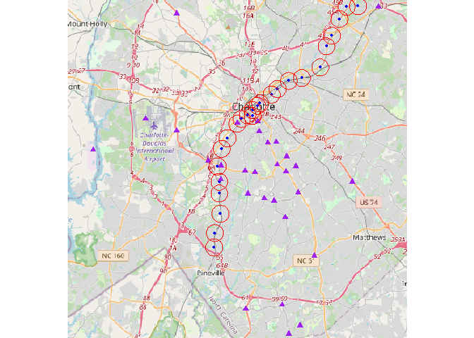

```r
# Plot Buffer around stations
# Target Buffer Radius =  800 meters
pts_buffer <- buffer(x, width = 800)

# Creating Buffer for Map
extent<-buffer(x, width = 200)

bg <- get_tiles(ext(extent), zoom = 11)

# Plots the background
plot(bg)

# pch=19 gives filled circles
points(x, col="blue", pch=19, cex=0.5)

# pch=17 gives filled triangles
points(pm_sources, col="purple", pch=17, cex=1)

# Plot the buffer around the stations
lines(pts_buffer, col="red")
```

Saving the Buffer’s into ShapeFile

```r
# First time users - do NOT over-wrrite CSV file
# writeVector(pts_buffer, "new_buffer_light_rail.shp")
```